**Link To GitHub Webpage: https://camdenyale.github.io/DataScienceProject/**

# **Geospatial Store Density and Regional Income Effects For Starbucks and Dunkin in the United States**

**Collaborators: Maeren Hay and Camden Yale**

## **Project Motivations**

Have you ever noticed that where you find a Starbucks seems different from where you find a Dunkin'? Our project uses store location data and census income figures to prove that this isn't random but instead calculated. We’re decoding the ultimate retail strategy: Dunkin' has achieved greater national reach, while Starbucks has perfected regional intensity. By running a statistical model, we can formally show how a city’s median income directly changes the probability of it being a Starbucks town versus a Dunkin' town.

This research is important because it uses two everyday coffee chains as a highly visible lens to reveal economic truths about America. By formally quantifying the Odds Ratios of these opposing strategies, we illustrate how major companies segment the nation based on wealth and population density, quantifying which brand has truly broken free of its founding region to achieve national dominance

## **Project Overview**

Our primary goal is to provide a quantitative and comparative analysis of the market strategies for Starbucks and Dunkin' in the United States by focusing on their geospatial distribution and correlation with local economic conditions.

**Objective: Logistic Regression Economic Correlation Model**

We will develop a multi-stage Logistic Regression Model to statistically quantify how local demographics influence the presence and market domination of each chain.

- Binary Logistic Regression
  - We will train two separate models (one for each chain) to determine the independent effect of median household income on the probability of a store's presence Starbucks_Present and Dunkin_Present.
- Multinomial Logistic Regression
  - We will train a single model using the categorical dependent variable, Dominant_Brand, to analyze how median household income shifts the odds of a city falling into one of four market states (Neither, Starbucks Dominant, Dunkin Dominant, or Equal Competition).

**Model Goals**

- Test the Income Hypothesis: Formally test the hypothesis that Dunkin' presence is negatively correlated with median household income, while Starbucks' presence is strongly driven by population density (POPESTIMATE2020) and is relatively neutral to income after controlling for city population size.
- Quantify Market Odds: Use the Odds Ratios from the Multinomial model to quantify how regional status and economic conditions change the likelihood of a city being in a Dunkin' dominant market or an Equal Competition market, relative to the Starbucks-dominant market baseline.

**Our Primary Research Questions**

1. Does the region of historical origin, the Northeast for Dunkin and the West for Starbucks, significantly affect the current geospatial presence of stores?
2. Does a city's median household income correlate with the presence of Starbucks and Dunkins?
3. Which chain is less reliant on its founding region for store existence, indicating greater national market reach and geographical spread?
4. Which chain converts its founding region status into stronger competitive dominance and greater store density over its rival?

## **Additional Resources**

Dunkin vs Starbucks Statistics:

https://cornercoffeestore.com/dunkin-donuts-vs-starbucks-statistics/

Starbucks vs Dunkin': An Expert Analysis of the Cofee Titans:

https://www.marketingscoop.com/consumer/starbucks-vs-dunkin/#google_vignette

## **Data Collection**

**Dunkin Dataset**

Link to the Dunkin dataset:  
https://www.kaggle.com/datasets/appleturnovers/dunkin-locations?resource=download&select=dunkin_stores.csv

**Starbucks Dataset**

The second dataset we are working with is the Starbucks Store Location 2023: Coffee Giant Growth dataset by Omar Sobhy. We obtained this dataset on kaggle.com. This dataset was created to enable customers to find Starbucks locations near them. Customers, researchers, and students interested in learning more about Starbucks have utilized this dataset. This dataset has 13 columns and 25,601 rows. Columns include Brand, Store Number, Store Name, Ownership Type, Street Address, City, State/Province, Country, Postcode, Phone Number, Timezone, Longitude, and Latitude. Every column except for longitude and latitude is inferred as an object, meaning they are classification variables. Longitude and Latitude pandas are inferred as float64s, meaning they are numerical variables. Even though pandas infers them as objects and float64, we will set our variable datatypes below to ensure they work best with our project. This dataset will help us answer our 3 major questions. Are there any regional disparities between the Northeast vs Everywhere else, North vs South, and East vs West? This, alongside our Dunkin Stores dataset, will serve as the foundation of our project. As we discover the geospatial density of Starbucks and Dunkin, it will enable us to include additional datasets to answer our questions listed in the key questions section. Below, we will tidy this dataset by ensuring it adheres to all tidy data principles learned in class, as well as filtering for Starbucks locations only in the United States and dropping unwanted columns. This dataset provides us with sufficient data to continue developing our model.

Link to the Starbucks dataset:  
https://www.kaggle.com/datasets/omarsobhy14/starbucks-store-location-2023/data

**Resident Population Dataset**

The third dataset we used is from the United States Census Bureau and is the Annual Estimates of the Resident Population for Incorporated Places in the United States: April 1st, 2020, to July 1st, 2024. The dataset is a CSV file with 81334 rows and 16 columns. The dataset has the following columns: SUMLEV, STATE, COUNTY, PLACE, COUSUB, CONCIT, PRIMGEO_FLAG, ESTIMATESBASE2020, POPESTIMATE2020, POPESTIMATE2021, POPESTIMATE2022, POPESTIMATE2023, and POPESTIMATE2024 of int64 types, and FUNCSTAT, NAME, and STNAME of object types. For the purpose of our project, we will drop most of these columns to end up with just the index, NAME (city), STNAME (state name), and POPESTIMATE2020 (the population estimates for 2020) since 2020 is closest to the years our other data was gathered. When observing the pandas inferred dtypes, they were all accurate and will not need changing. We are using this population dataset to normalize the raw store counts so we can properly measure the geospatial density of Starbucks and Dunkin stores. This dataset provides us with sufficient data to continue developing our model.

Link to City Population Dataset:  
https://www.census.gov/data/datasets/time-series/demo/popest/2020s-total-cities-and-towns.html

**Median Household Income**

The fourth dataset we used is the US Household Income Statistics from Golden Oak Research Group. We obtained this dataset on kaggle.com. This dataset was created to allow easy, usable, and accurate manipulation of U.S Census data. Students, data analysts, and the general population have used this dataset for various calculations and projects. The dataset has 19 columns and over 32,000 rows. Columns include id, State_Code, State_Name, State_Ab, County, City, Place, Type, Primary, Zip_Code, Area_Code, ALand, AWater, Lat, Lon, Mean, Median, Stdev, and sum_w. However, we will drop many columns while cleaning our dataset to better align with our project goals. Pandas inferred all of our rows except Zip_Code, Lat, Lon, Mean, Median, Stdev which were either int64 or float64. This makes since these columns are numerical and the rest of the columns are classification columns. Even though pandas inferred our variables like this, we will set our column datatypes below to ensure they work best with our project. This dataset will help us explore and analyze the relationship between household income and the locations of Starbucks and Dunkin stores. Specifically, it will help us determine whether these stores are more concentrated in higher-income or lower-income neighborhoods based on average income. This will help us in our goal to discover if the average household income of a city elicits certain marketing strategies. Below, we will tidy this dataset by ensuring it adheres to all tidy data principles learned in class and dive into dtypes. This dataset provides us with sufficient data to continue developing our model.

Link to the Median Income dataset:  
https://www.kaggle.com/datasets/goldenoakresearch/us-household-income-stats-geo-locations?select=kaggle_income.csv

## **ETL (Extract, Transform, Load)**

This code is essential for setting up our Python environment by importing necessary libraries and configuring paths to our datasets. We import kagglehub in order to directly access datasets from Kaggle. We import the pandas (as pd) library for working with CSV files efficiently. Then we import the numpy library (as np) for calculations and transformations of our data. Import matplotlib.pyplot (as plt) is crucial for creating visualizations in Python. We import os to make our file paths work with different operating systems, and import drive from google.colab to access files on our drive. Finally, we import LogisticRegression from scikitlearn to create our logisitic regression model, and we import roc_auc_score and accuracy_score from scikitlearn to validate our model. This is important since our logistic regression model is explanatory, not predicitive. This is replacing the validation we get from splitting our training and testing data, which is not necessary in an explanatory model.

```python
# Necessary imports
import kagglehub
import pandas as pd
import os
import numpy as np
import matplotlib.pyplot as plt
from google.colab import drive
from sklearn.preprocessing import StandardScaler
from sklearn.linear_model import LogisticRegression
from sklearn.metrics import roc_auc_score, accuracy_score

# Path to the Dunkin dataset from Kaggle
dunkin_path = kagglehub.dataset_download("appleturnovers/dunkin-locations")

# Path to the Starbucks dataset from Kaggle
starbucks_path = kagglehub.dataset_download("omarsobhy14/starbucks-store-location-2023")

# Path to the Median Household Income dataset from Kaggle
household_income_path = kagglehub.dataset_download("goldenoakresearch/us-household-income-stats-geo-locations")

# Mount our drive that has our dataset
drive.mount('/content/drive')

# Path to the City Population dataset from Kaggle
file_path='/content/drive/MyDrive/sub-est2024.csv'
```

```
Using Colab cache for faster access to the 'dunkin-locations' dataset.
Using Colab cache for faster access to the 'starbucks-store-location-2023' dataset.
Using Colab cache for faster access to the 'us-household-income-stats-geo-locations' dataset.
```

### **Dunkin Dataset**

Load original Dunkin dataset. We did this using the pandas library read_csv function, since our dataframe is in a comma seperated values format.

```python
# Read the Starbucks dataset from kaggle as a CSV
original_dunkin = pd.read_csv(os.path.join(dunkin_path, 'dunkin_stores.csv'))
```

View original Dunkin dataset

```python
# Dispay the first 5 rows of our dataframe using .head()
original_dunkin.head()
```

|  | row_id | address_line_1 | address_line_2 | city | state | zip | phone | mon_hrs | tue_hrs | wed_hrs | ... | sat_hrs | sun_hrs | drive-thru | mobile-order | dunkin-card | kcup | curbside-pickup | has-baskin-robbins | loc_lat | loc_long |
| --- | --- | --- | --- | --- | --- | --- | --- | --- | --- | --- | --- | --- | --- | --- | --- | --- | --- | --- | --- | --- | --- |
| 0 | 0 | 1114 1st St N | Suite 200 | Alabaster | AL | 35007 | (205) 624-4880 | 5:00 AM - 8:00 PM | 5:00 AM - 8:00 PM | 5:00 AM - 8:00 PM | ... | 6:00 AM - 8:00 PM | 6:00 AM - 8:00 PM | True | False | True | True | False | False | NaN | NaN |
| 1 | 1 | 8171 US Highway 431 | NaN | Albertville | AL | 35950 | (256) 869-6075 | 5:00 AM - 9:00 PM | 5:00 AM - 9:00 PM | 5:00 AM - 9:00 PM | ... | 5:00 AM - 10:00 PM | 5:00 AM - 9:00 PM | True | True | True | False | False | True | NaN | NaN |
| 2 | 2 | 1700 US Highway 72 E | NaN | Athens | AL | 35611 | (256) 960-9302 | 5:00 AM - 8:00 PM | 5:00 AM - 8:00 PM | 5:00 AM - 8:00 PM | ... | 5:00 AM - 8:00 PM | 5:00 AM - 8:00 PM | True | True | True | True | False | False | 34.781698 | -86.934524 |
| 3 | 3 | 171 N College St | NaN | Auburn | AL | 36830 | (334) 707-8552 | 6:00 AM - 3:00 PM | 6:00 AM - 3:00 PM | 6:00 AM - 3:00 PM | ... | 6:00 AM - 3:00 PM | 6:00 AM - 3:00 PM | False | False | True | True | False | False | 32.608800 | -85.481849 |
| 4 | 4 | 2049 S College St | NaN | Auburn | AL | 36832 | (334) 501-2233 | 5:00 AM - 8:00 PM | 5:00 AM - 8:00 PM | 5:00 AM - 8:00 PM | ... | 5:00 AM - 8:00 PM | 6:00 AM - 8:00 PM | True | True | True | True | False | False | 32.567323 | -85.501589 |

5 rows × 22 columns

Tidying this dataset consisted of dropping unwanted columns from our dataframe. Next, we wanted one address row instead of two to comply with the attributes of tidy data we learned in class. Therefore, we decided to join address_line_1 and address_line_2 using numpy. We used numpy so that we could exclude data under address_line_2 that was NaN, and append present data to address_line_1 in parenthesis. We considered re-ordering the hours for the days of the week by creating a 'days' and 'hours' column. This did not work because it caused repetitions of our observations, and our purpose in this phase is to keep the location and row_id variables unique; therefore, we decided to omit the hours and days of the week.

Finally, we removed the row_id column and instead renamed the index 'row_id' to eliminate redundancy.

```python
# Use .drop to exclude unwanted columns in our final dunkin dataframe. Made the row_id our primary index
final_dunkin= original_dunkin.drop(columns=['drive-thru', 'mobile-order', 'dunkin-card', 'kcup', 'curbside-pickup', 'has-baskin-robbins', 'row_id', 'mon_hrs','tue_hrs', 'wed_hrs', 'thu_hrs', 'fri_hrs', 'sat_hrs', 'sun_hrs'])
final_dunkin.index.name = 'row_id'

# Having two seperate columns for address line 1 and 2 was not tidy, use numpy to join non-empty address_line_2 names with address_line_1 in parenthesis to create a single address line column
final_dunkin['address'] = np.where(
    pd.notna(final_dunkin['address_line_2']),
    final_dunkin['address_line_1'] + ' (' + final_dunkin['address_line_2'] + ')',
    final_dunkin['address_line_1']
)
# Drop the previous address line columns since we replaced them with a single column
final_dunkin = final_dunkin.drop(columns=['address_line_1', 'address_line_2'])
```

Print Pandas inferred dtypes of Dunkin dataset

```python
# .dtypes displays the data type of each column in the dataframe
print(final_dunkin.dtypes)
```

```
city         object
state        object
zip           int64
phone        object
loc_lat     float64
loc_long    float64
address      object
dtype: object
```

Map correct dtypes for final Dunkin dataset

First, we changed the city and state to a category instead of an object. Doing this makes grouping more efficient and uses less memory. We then needed to change zip to be an object instead of an int64. An object allows us to treat it as a string instead of a number. Since we are not performing any numerical calculations, and Zip_Code is used as an identifier, int64 would be an incorrect datatype and could cause errors.Our final_dunkin holds our tidy dataset and will be used in our analysis throughout the remainder of this project.

```python
# Map the columns whose dtypes need to change
dtype_mapping = { 'city': 'category', 'state':
                 'category', 'zip': 'object'}
final_dunkin = final_dunkin.astype(dtype_mapping)
```

View the final, mapped datatypes

```python
# .dtypes displays the data type of each column in the dataframe after mapping
print(final_dunkin.dtypes)
```

```
city        category
state       category
zip           object
phone         object
loc_lat      float64
loc_long     float64
address       object
dtype: object
```

View final Dunkin dataset

```python
# Dispay the first 5 rows of our final, cleaned dataframe using .head()
final_dunkin.head()
```

| row_id | city | state | zip | phone | loc_lat | loc_long | address |
| --- | --- | --- | --- | --- | --- | --- | --- |
| 0 | Alabaster | AL | 35007 | (205) 624-4880 | NaN | NaN | 1114 1st St N (Suite 200) |
| 1 | Albertville | AL | 35950 | (256) 869-6075 | NaN | NaN | 8171 US Highway 431 |
| 2 | Athens | AL | 35611 | (256) 960-9302 | 34.781698 | -86.934524 | 1700 US Highway 72 E |
| 3 | Auburn | AL | 36830 | (334) 707-8552 | 32.608800 | -85.481849 | 171 N College St |
| 4 | Auburn | AL | 36832 | (334) 501-2233 | 32.567323 | -85.501589 | 2049 S College St |

### **Starbucks Dataset**

Load the original Starbucks dataset. We use the pandas library read_csv function since our dataframe is comma seperated.

```python
# Read the Starbucks dataset from kaggle as a CSV
original_starbucks_df = pd.read_csv(
   os.path.join(starbucks_path, 'Starbucks Store Locations.csv'),
   encoding='latin1'  # Use Latin-1 encoding to prevent Unicode errors from special characters
)
```

View the original dataset

```python
# Display the first 5 rows of our dataframe
original_starbucks_df.head()
```

|  | Brand | Store Number | Store Name | Ownership Type | Street Address | City | State/Province | Country | Postcode | Phone Number | Timezone | Longitude | Latitude |
| --- | --- | --- | --- | --- | --- | --- | --- | --- | --- | --- | --- | --- | --- |
| 0 | Starbucks | 47370-257954 | Meritxell, 96 | Licensed | Av. Meritxell, 96 | Andorra la Vella | 7 | AD | AD500 | 376818720 | GMT+1:00 Europe/Andorra | 1.53 | 42.51 |
| 1 | Starbucks | 22331-212325 | Ajman Drive Thru | Licensed | 1 Street 69, Al Jarf | Ajman | AJ | AE | NaN | NaN | GMT+04:00 Asia/Dubai | 55.47 | 25.42 |
| 2 | Starbucks | 47089-256771 | Dana Mall | Licensed | Sheikh Khalifa Bin Zayed St. | Ajman | AJ | AE | NaN | NaN | GMT+04:00 Asia/Dubai | 55.47 | 25.39 |
| 3 | Starbucks | 22126-218024 | Twofour 54 | Licensed | Al Salam Street | Abu Dhabi | AZ | AE | NaN | NaN | GMT+04:00 Asia/Dubai | 54.38 | 24.48 |
| 4 | Starbucks | 17127-178586 | Al Ain Tower | Licensed | Khaldiya Area, Abu Dhabi Island | Abu Dhabi | AZ | AE | NaN | NaN | GMT+04:00 Asia/Dubai | 54.54 | 24.51 |

To tidy this dataset, we started by dropping unwanted columns. We decided we no longer needed "Store Name" or "Ownership Type" because they serve no direct correlation to our Dunkin dataset. The Store Number column is sufficient.

We then needed to sort our data so it only includes Starbucks locations in the United States. We did this by finding all rows where the 'Country' column matched 'US'. This was necessary because we are not comparing Starbucks and Dunkin locations worldwide, but nationally. We kept all other columns as they will help us in tracking our geospatial density.

```python
# Use the .drop function and select the unwanted columns, select the coutntry column of the DF and sort the entries to include only stores in the US, store the cleaned result in a new dataframe
final_starbucks_df = original_starbucks_df.drop(columns=['Store Name', 'Ownership Type'])[original_starbucks_df["Country"] == "US"]
```

View what pandas inferrs our datatypes to be so we can decide if we want to set them differently.

```python
# .dtypes displays the data type of each column in the dataframe
print(final_starbucks_df.dtypes)
```

```
Brand              object
Store Number       object
Street Address     object
City               object
State/Province     object
Country            object
Postcode           object
Phone Number       object
Timezone           object
Longitude         float64
Latitude          float64
dtype: object
```

Pandas inferred our datatypes to be all objects except for Longitude and Latitude, which are float64. Pandas correctly inferred Longitude and Latitude, so we did not have to map new data types to those variables. Postcode, Phone Number, and Street Address, which were assigned the object datatype, stayed the same because they are unique values. We will change the variables Brand, Store Number, City, State/Province, Country, and Timezone to have a category datatype instead of an object. This is more efficient than treating them like an object because it is faster and takes less memory. Our final_starbucks_df holds our tidy dataset and will be used in our analysis throughout the remainder of this project.

```python
# Map the columns whose dtypes need to change
dtype_mapping = {
   'Brand': 'category',
   'Store Number': 'category',
   'City': 'category',
   'State/Province': 'category',
   'Country': 'category',
   'Timezone': 'category',
}
final_starbucks_df = final_starbucks_df.astype(dtype_mapping)
```

View the mapped datatypes

```python
# .dtypes displays the data type of each column in the dataframe after mapping
print(final_starbucks_df.dtypes)
```

```
Brand             category
Store Number      category
Street Address      object
City              category
State/Province    category
Country           category
Postcode            object
Phone Number        object
Timezone          category
Longitude          float64
Latitude           float64
dtype: object
```

View the tidied dataset

```python
# Dispay the first 5 rows of our final, cleaned dataframe
final_starbucks_df.head()
```

|  | Brand | Store Number | Street Address | City | State/Province | Country | Postcode | Phone Number | Timezone | Longitude | Latitude |
| --- | --- | --- | --- | --- | --- | --- | --- | --- | --- | --- | --- |
| 11965 | Starbucks | 3513-125945 | 5600 Debarr Rd Ste 9 | Anchorage | AK | US | 995042300 | 907-339-0900 | GMT-09:00 America/Anchorage | -149.78 | 61.21 |
| 11966 | Starbucks | 74352-84449 | 1725 Abbott Rd | Anchorage | AK | US | 995073444 | 907-339-2800 | GMT-09:00 America/Anchorage | -149.84 | 61.14 |
| 11967 | Starbucks | 12449-152385 | 1501 Huffman Rd | Anchorage | AK | US | 995153596 | 907-339-1300 | GMT-09:00 America/Anchorage | -149.85 | 61.11 |
| 11968 | Starbucks | 24936-233524 | 320 W. 100th Ave, 100, Southgate Shopping Ctr ... | Anchorage | AK | US | 99515 | (907) 227-9631 | GMT-09:00 America/Anchorage | -149.89 | 61.13 |
| 11969 | Starbucks | 8973-85630 | 1005 E Dimond Blvd | Anchorage | AK | US | 995152050 | 907-344-4160 | GMT-09:00 America/Anchorage | -149.86 | 61.14 |

### **City Population Dataset**

Load the original population dataset. We again used the pandas read_csv function. We also added Latin-1 encoding in our parameters to prevent Unicode errors from special characters.

```python
# Read the population dataset as a CSV
original_population_df= pd.read_csv(file_path, encoding='latin1')  # Use Latin-1 encoding to prevent Unicode errors from special characters
```

View original dataset

```python
# Dispay the first 5 rows of our dataframe using .head()
original_population_df.head()
```

|  | SUMLEV | STATE | COUNTY | PLACE | COUSUB | CONCIT | PRIMGEO_FLAG | FUNCSTAT | NAME | STNAME | ESTIMATESBASE2020 | POPESTIMATE2020 | POPESTIMATE2021 | POPESTIMATE2022 | POPESTIMATE2023 | POPESTIMATE2024 |
| --- | --- | --- | --- | --- | --- | --- | --- | --- | --- | --- | --- | --- | --- | --- | --- | --- |
| 0 | 40 | 1 | 0 | 0 | 0 | 0 | 0 | A | Alabama | Alabama | 5025369 | 5033094 | 5049196 | 5076181 | 5117673 | 5157699 |
| 1 | 162 | 1 | 0 | 124 | 0 | 0 | 0 | A | Abbeville city | Alabama | 2349 | 2349 | 2329 | 2328 | 2337 | 2370 |
| 2 | 162 | 1 | 0 | 460 | 0 | 0 | 0 | A | Adamsville city | Alabama | 4393 | 4381 | 4315 | 4251 | 4204 | 4181 |
| 3 | 162 | 1 | 0 | 484 | 0 | 0 | 0 | A | Addison town | Alabama | 661 | 659 | 665 | 670 | 669 | 676 |
| 4 | 162 | 1 | 0 | 676 | 0 | 0 | 0 | A | Akron town | Alabama | 229 | 228 | 229 | 226 | 229 | 233 |

Drop unwanted columns

```python
# Use the .drop function and select the unwanted columns, store the cleaned result in a new dataframe
final_population_df=original_population_df.drop(columns=["SUMLEV", "STATE", "COUNTY", "PLACE", "COUSUB", "CONCIT", "PRIMGEO_FLAG", "FUNCSTAT", "ESTIMATESBASE2020", "POPESTIMATE2021", "POPESTIMATE2022", "POPESTIMATE2023", "POPESTIMATE2024"])

# Clean the 'NAME' column by removing " city"
final_population_df['NAME'] = final_population_df['NAME'].str.replace(' city', '', case=False, regex=False)

# Clean the 'NAME' column by removing " town"
final_population_df['NAME'] = final_population_df['NAME'].str.replace(' town', '', case=False, regex=False)

# Strip any resulting extra whitespace from the ends
final_population_df['NAME'] = final_population_df['NAME'].str.strip()

# Rename the NAME column to 'City'
final_population_df.rename(columns={'NAME': 'City'}, inplace=True)
```

Show pandas inferred dtypes

```python
# .dtypes displays the data type of each column in the dataframe
print(final_population_df.dtypes)
```

```
City               object
STNAME             object
POPESTIMATE2020     int64
dtype: object
```

All dtypes were inferred correctly. No need to change any.

View the tidied dataset

```python
# Dispay the first 5 rows of our final, cleaned dataframe using .head()
final_population_df.head()
```

|  | City | STNAME | POPESTIMATE2020 |
| --- | --- | --- | --- |
| 0 | Alabama | Alabama | 5033094 |
| 1 | Abbeville | Alabama | 2349 |
| 2 | Adamsville | Alabama | 4381 |
| 3 | Addison | Alabama | 659 |
| 4 | Akron | Alabama | 228 |

### **Median Income Dataset**

Load the original median income dataset. We used the read_csv pandas function onces again, and included latin1 encoding to prevent Unicode errors.

```python
# Read the median income dataset from kaggle as a CSV
original_median_income_df = pd.read_csv(
    os.path.join(household_income_path, 'kaggle_income.csv'),
    encoding='latin1' # Use Latin-1 encoding to prevent Unicode errors from special characters
)
```

View the original dataset

```python
# Dispay the first 5 rows of our dataframe using .head()
original_median_income_df.head()
```

|  | id | State_Code | State_Name | State_ab | County | City | Place | Type | Primary | Zip_Code | Area_Code | ALand | AWater | Lat | Lon | Mean | Median | Stdev | sum_w |
| --- | --- | --- | --- | --- | --- | --- | --- | --- | --- | --- | --- | --- | --- | --- | --- | --- | --- | --- | --- |
| 0 | 1011000 | 1 | Alabama | AL | Mobile County | Chickasaw | Chickasaw city | City | place | 36611 | 251 | 10894952 | 909156 | 30.771450 | -88.079697 | 38773 | 30506 | 33101 | 1638.260513 |
| 1 | 1011010 | 1 | Alabama | AL | Barbour County | Louisville | Clio city | City | place | 36048 | 334 | 26070325 | 23254 | 31.708516 | -85.611039 | 37725 | 19528 | 43789 | 258.017685 |
| 2 | 1011020 | 1 | Alabama | AL | Shelby County | Columbiana | Columbiana city | City | place | 35051 | 205 | 44835274 | 261034 | 33.191452 | -86.615618 | 54606 | 31930 | 57348 | 926.031000 |
| 3 | 1011030 | 1 | Alabama | AL | Mobile County | Satsuma | Creola city | City | place | 36572 | 251 | 36878729 | 2374530 | 30.874343 | -88.009442 | 63919 | 52814 | 47707 | 378.114619 |
| 4 | 1011040 | 1 | Alabama | AL | Mobile County | Dauphin Island | Dauphin Island | Town | place | 36528 | 251 | 16204185 | 413605152 | 30.250913 | -88.171268 | 77948 | 67225 | 54270 | 282.320328 |

Drop unwanted columns

```python
# Use the .drop function and select the unwanted columns, store the cleaned result in a new dataframe
final_median_income_df = original_median_income_df.drop(columns=['ALand', 'AWater', 'id', 'Primary', 'sum_w', 'State_Code'])
```

View what pandas inferrs our datatypes to be so we can decide if we want to set them differently.

```python
# .dtypes displays the data type of each column in the dataframe
print(final_median_income_df.dtypes)
```

```
State_Name     object
State_ab       object
County         object
City           object
Place          object
Type           object
Zip_Code        int64
Area_Code      object
Lat           float64
Lon           float64
Mean            int64
Median          int64
Stdev           int64
dtype: object
```

Change the variable datatypes to better align with our project goals.

We needed to change Zip_Code to be an object instead of an int64. An object allows us to treat it as a string instead of a number. Since we are not performing any numerical calculations, and Zip_Code is used as an identifier, int64 would be an incorrect datatype and could cause errors.

```python
# Map the columns whose dtypes need to change
dtype_mapping = {
  'Zip_Code': 'object', # Change the Zip_Code column to an object instead of int64 so it can be treated as a string
}
final_median_income_df = final_median_income_df.astype(dtype_mapping)
```

View the mapped datatypes

```python
# .dtypes displays the data type of each column in the dataframe after mapping Zip_Code
print(final_median_income_df.dtypes)
```

```
State_Name     object
State_ab       object
County         object
City           object
Place          object
Type           object
Zip_Code       object
Area_Code      object
Lat           float64
Lon           float64
Mean            int64
Median          int64
Stdev           int64
dtype: object
```

View the tidied dataset

```python
# Dispay the first 5 rows of our final, cleaned dataframe using .head()
final_median_income_df.head()
```

|  | State_Name | State_ab | County | City | Place | Type | Zip_Code | Area_Code | Lat | Lon | Mean | Median | Stdev |
| --- | --- | --- | --- | --- | --- | --- | --- | --- | --- | --- | --- | --- | --- |
| 0 | Alabama | AL | Mobile County | Chickasaw | Chickasaw city | City | 36611 | 251 | 30.771450 | -88.079697 | 38773 | 30506 | 33101 |
| 1 | Alabama | AL | Barbour County | Louisville | Clio city | City | 36048 | 334 | 31.708516 | -85.611039 | 37725 | 19528 | 43789 |
| 2 | Alabama | AL | Shelby County | Columbiana | Columbiana city | City | 35051 | 205 | 33.191452 | -86.615618 | 54606 | 31930 | 57348 |
| 3 | Alabama | AL | Mobile County | Satsuma | Creola city | City | 36572 | 251 | 30.874343 | -88.009442 | 63919 | 52814 | 47707 |
| 4 | Alabama | AL | Mobile County | Dauphin Island | Dauphin Island | Town | 36528 | 251 | 30.250913 | -88.171268 | 77948 | 67225 | 54270 |

### **Standardization**

```python
# Organize our final dataframes into a dictonary for easy access
dataframes = {
    'dunkin': final_dunkin,
    'starbucks': final_starbucks_df,
    'population': final_population_df,
    'income': final_median_income_df
}

# Create a map to standardize columns so they can be referenced using the same column name
rename_maps = {
    # Dunkin Dataset Map
    'dunkin': {
        'state': 'state_name',
        'city': 'city_name',
        'zip': 'zip_code',
        'loc_lat': 'latitude',
        'loc_long': 'longitude'
    },
    # Starbucks Dataset Map
    'starbucks': {
        'State/Province': 'state_name',
        'City': 'city_name',
        'Postcode': 'zip_code',
        'Latitude': 'latitude',
        'Longitude': 'longitude'
    },
    # Population Dataset Map
    'population': {
        'STNAME': 'state_name',
        'NAME': 'city_name',
    },
    # Income Dataset Map
    'income': {
        'State_Name': 'state_name',
        'City': 'city_name',
        'Zip_Code': 'zip_code',
        'Lat': 'latitude',
        'Lon': 'longitude'
    }
}

# Rename columns and standardize entries for city and state name
for name, df in dataframes.items():
    df.rename(columns=rename_maps[name], inplace=True)
    for col in ['state_name', 'city_name']:
        if col in df.columns:
            df[col] = df[col].astype(str).str.upper().str.strip()

# Map states to their abbreviation
state_to_abbrev = {
    'Alabama': 'AL', 'Alaska': 'AK', 'Arizona': 'AZ', 'Arkansas': 'AR', 'California': 'CA',
    'Colorado': 'CO', 'Connecticut': 'CT', 'Delaware': 'DE', 'District of Columbia': 'DC',
    'Florida': 'FL', 'Georgia': 'GA', 'Hawaii': 'HI', 'Idaho': 'ID', 'Illinois': 'IL',
    'Indiana': 'IN', 'Iowa': 'IA', 'Kansas': 'KS', 'Kentucky': 'KY', 'Louisiana': 'LA',
    'Maine': 'ME', 'Maryland': 'MD', 'Massachusetts': 'MA', 'Michigan': 'MI',
    'Minnesota': 'MN', 'Mississippi': 'MS', 'Missouri': 'MO', 'Montana': 'MT',
    'Nebraska': 'NE', 'Nevada': 'NV', 'New Hampshire': 'NH', 'New Jersey': 'NJ',
    'New Mexico': 'NM', 'New York': 'NY', 'North Carolina': 'NC', 'North Dakota': 'ND',
    'Ohio': 'OH', 'Oklahoma': 'OK', 'Oregon': 'OR', 'Pennsylvania': 'PA',
    'Rhode Island': 'RI', 'South Carolina': 'SC', 'South Dakota': 'SD', 'Tennessee': 'TN',
    'Texas': 'TX', 'Utah': 'UT', 'Vermont': 'VT', 'Virginia': 'VA', 'Washington': 'WA',
    'West Virginia': 'WV', 'Wisconsin': 'WI', 'Wyoming': 'WY', 'Puerto Rico': 'PR'
}
```

Standardizing is critical for our final Logistic Regression Model. We first started by making a single dictionary that contains all of our final dataset dataframes. Each final dataframe is a descriptive key. This makes our dataframes more easily accessible and reusable. Next, we standardized the shared column names across datasets to ensure key variables can be accessed using only one name by mapping. Finally, we made a mapping feature that maps all full state names to their abbreviations. This ensures that we maximize our match rate when doing an inner merge later. We also cleaned our data by converting entries to uppercase and removing extra whitespace. This keeps our data uniform and prevents errors when merging.

## **EDA (Exploratory Data Analysis)**

Create a mapping that maps states to their respective regions

```python
# Map each U.S state to its corresponding census region
regions_mapping = {
    # Northeast Region
    'ME': 'Northeast', 'VT': 'Northeast', 'NH': 'Northeast', 'MA': 'Northeast',
    'RI': 'Northeast', 'CT': 'Northeast', 'NY': 'Northeast', 'NJ': 'Northeast',
    'PA': 'Northeast',
    # Midwest Region
    'OH': 'Midwest', 'IN': 'Midwest', 'IL': 'Midwest', 'MI': 'Midwest', 'WI': 'Midwest',
    'MN': 'Midwest', 'IA': 'Midwest', 'MO': 'Midwest', 'ND': 'Midwest', 'SD': 'Midwest',
    'NE': 'Midwest', 'KS': 'Midwest',
    # South Region
    'DE': 'South', 'MD': 'South', 'DC': 'South', 'VA': 'South', 'WV': 'South',
    'NC': 'South', 'SC': 'South', 'GA': 'South', 'FL': 'South', 'KY': 'South',
    'TN': 'South', 'AL': 'South', 'MS': 'South', 'AR': 'South', 'LA': 'South',
    'OK': 'South', 'TX': 'South',
    # West Region
    'MT': 'West', 'ID': 'West', 'WY': 'West', 'CO': 'West', 'NM': 'West', 'AZ': 'West',
    'UT': 'West', 'NV': 'West', 'WA': 'West', 'OR': 'West', 'CA': 'West', 'AK': 'West',
    'HI': 'West',
    # Territories
    'PR': 'Other'
}
```

### **Dunkin Statistics**

#### **Total Dunkin locations by region**

Get a count for Dunkin stores in each region by temporarily mapping the 'State/Province' column to the region mapping above. Then, count the number of entries in each region.

```python
# Map each state in the dunkin dataset to its corresponding region using .map(), then count how many stores are in each region using .value_counts()
dunkin_regional_counts = final_dunkin['state_name'].map(regions_mapping).value_counts()
```

View the total Dunkin locations by region

```python
# Loop through the regional counts and print how many dunkins are in each region
for region, count in dunkin_regional_counts.items():
  print(f"Dunkin locations in the {region}: {count}")
```

```
Dunkin locations in the Northeast: 5047
Dunkin locations in the South: 2493
Dunkin locations in the Midwest: 1373
Dunkin locations in the West: 335
```

The first thing we had to do is map each state abbreviation to its corresponding region. Specifying regions is important to understand the Geospatial Analysis and Regional Disparity. After using .map() and .value_count() to determine the total number of Dunkin locations in each region, we made a for loop to print each regions data. This helps us show the regional distribution of Dunkin locations. We can connect this to historical roots and market saturation in non-founding regions. For example, we see Dunkin has many more locations in the Northeast, its founding region, compared to less than 500 in the West, Starbucks founding region. By starting with these simple counts we can it gives us a foundation to do more complex analysis later on.

### **Starbucks Statistics**

#### **Total Starbucks locations by region**

Get a count for Starbucks stores in each region by temporarily mapping the 'State/Province' column to the region mapping above. Use value counts to count the number of entries in each region.

```python
#  Map each state in the starbucks dataset to its corresponding region using .map(), then count how many stores are in each region using .value_counts()
starbucks_regional_counts = (final_starbucks_df['state_name'].map(regions_mapping).value_counts())
```

View the total Starbucks locations by region

```python
# Loop through the regional counts and print how many starbucks are in each region
for region, count in starbucks_regional_counts.items():
    print(f"Starbucks locations in the {region}: {count}")
```

```
Starbucks locations in the West: 5610
Starbucks locations in the South: 3992
Starbucks locations in the Midwest: 2253
Starbucks locations in the Northeast: 1753
```

For the Starbucks regional counts we use the same region mapping specified above. Specifying regions is important to understand the Geospatial Analysis and Regional Disparity. After using .map() and .value_count() to determine the total number of Starbucks locations in each region, we made a for loop to print each regions data. This helps shows the regional distribution of Starbucks locations. We can connect this to historical roots and market saturation in non-founding regions. For example, Starbucks has the most stores in the West, its founding region, and the least in the Northeast (Dunkin's founding region). By starting with these simple counts it gives us a foundation to do more complex analysis later on.

### **Regions Visual**

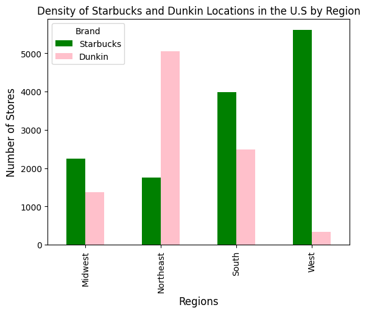

```python
# Create a dataframe combining starbucks and dunkin locations regional count
# Fill missing values with 0 and convert counts to integers
starbucks_and_dunkin_df = pd.DataFrame({
  'Starbucks': starbucks_regional_counts,
  'Dunkin': dunkin_regional_counts
}).fillna(0).astype(int)

# Plot a bar chart comparing regional counts, green for starbucks and pink for dunkin
starbucks_and_dunkin_df.plot(kind='bar', color=['green', 'pink'])

# Customize our graph with titles, labels, and legends
plt.title('Density of Starbucks and Dunkin Locations in the U.S by Region')
plt.xlabel('Regions', fontsize=12)
plt.ylabel('Number of Stores', fontsize=12)
plt.legend(title='Brand', loc='upper left')
```

This bar graph compares the number of Starbucks and Dunkin store locations across the U.S regions. We utilized the Starbucks and Dunkin datasets and mapped them by region. This will give us a great understanding of the Geospatial Analysis and Regional Disparity. To create this visualization, we used the regional store counts for each brand and combined them into a single dataframe. Starbucks is represented by the green bars, while Dunkin is represented by the pink bar. From this visual, we can see some pretty extreme distributions of locations.

- Starbucks has more than 5,000 locations in the West.
- Dunkin has fewer than 500 locations in the West.
- Dunkin's strong region is the Northeast.

These patterns help us answer our first research question because it suggest, yes, there are regional disparities. Dunkin’ dominates in the Northeast (its origin), and Starbucks dominates in the West (its origin).

### **City Population Statistics**

```python
# COUNT STORES PER CITY
# Aggregate the raw store location data to get a single count per city/state pair

# Group Dunkin' data by the standardized 'city_name' and 'state_name' and count stores
dunkin_counts = final_dunkin.groupby(['city_name', 'state_name']).size().reset_index(name='Dunkin_Count')

# Do same for Starbucks stores
starbucks_counts = final_starbucks_df.groupby(['city_name', 'state_name']).size().reset_index(name='Starbucks_Count')

# Merge the two store counts together on the standardized keys: 'city_name' and 'state_name'
store_counts_df = pd.merge(dunkin_counts, starbucks_counts, on=['city_name', 'state_name'], how='outer').fillna(0)

# MERGE WITH POPULATION DATA
# To correctly inner join population data with store counts, we clean and standardize the population data

# To preserve the original Dataframe, create a copy of population data to work with
population_df = final_population_df.copy() #note: when copying final pop df, the standardized column names do not carry over

# Rename columns to standardized 'city_name' and 'state_name' (redo since overidden in copy)
population_df.rename(columns={'City': 'city_name', 'STNAME': 'state_name'}, inplace=True)

# *IMPORTANT*
# This ensures 'state_name' column that is currently full names, can be matched to the state_abbrev dict we made above
population_df['state_name'] = (
    population_df['state_name']
    .str.strip().str.title() # Strip extra white space, and convert to uppercase for clear formatting
    .map(state_to_abbrev) # Maps 'New York' --> 'NY'
    .str.upper() # Ensures uppercase to match with store data format
)

# Convert the population estimate of 2020 to numeric. Strings or nulls are coerced to NaN
population_df['POPESTIMATE2020'] = pd.to_numeric(population_df['POPESTIMATE2020'], errors='coerce')

# Final standardization of city names, stripping extra whitespace and ensuring uppercase
population_df['city_name'] = population_df['city_name'].astype(str).str.upper().str.strip()

# Drop NaNs after mapping to cleanup where standardization failed
population_df.dropna(subset=['city_name', 'state_name', 'POPESTIMATE2020'], inplace=True)

# INNER MERGE between store counts and the new tidied population data.
# We chose inner merge to only analyze cities that have complete store counts AND population data
city_analysis_df = pd.merge(
    store_counts_df,
    population_df,
    on=['city_name', 'state_name'],
    how='inner'
)

# Filter out records where population is too low (below 1000) so that our per capita calculation is stable
city_analysis_df = city_analysis_df[city_analysis_df['POPESTIMATE2020'] >= 1000]

# CALCULATE STORE DENSITY PER CAPITA
# Now we want to normalize store counts by population to create an accurate strore density metric for our y-axis

# Define the scale factor (per 10,000 residents)
POP_SCALE = 10000
# Calculate store density for each chain: store count/ population count
city_analysis_df['Dunkin_Density'] = (city_analysis_df['Dunkin_Count'] / city_analysis_df['POPESTIMATE2020']) * POP_SCALE
city_analysis_df['Starbucks_Density'] = (city_analysis_df['Starbucks_Count'] / city_analysis_df['POPESTIMATE2020']) * POP_SCALE

# TOTAL STORES PRE-MERGE
# Get the total count of stores from our Dunkin and Starbucks datasets before the merge
total_dunkin_stores = final_dunkin.shape[0]
total_starbucks_stores = final_starbucks_df.shape[0]

# Identify the successful merge keys by getting the unique list of (city_name, state_name) pairs that successfully merged with population data. Used drop_duplicates for a unique list.
successful_keys = city_analysis_df[['city_name', 'state_name']].drop_duplicates()

# TOTAL MATCHED STORES
# Calculate the count of matched stores by merging the original store data with the successful city keys.

# Dunkin' Match Count
matched_dunkin_stores = final_dunkin.merge(
    successful_keys,
    on=['city_name', 'state_name'],
    how='inner'# inner merge to include all matches
).shape[0] # shape[0] gives us the exact count of individual stores matched

# Starbucks Match Count
matched_starbucks_stores = final_starbucks_df.merge(
    successful_keys,
    on=['city_name', 'state_name'],
    how='inner'
).shape[0]

# CALCULATE MATCH RATES

# Calculate match rates by dividing the amount of matches stores by the amount of total stores before merging with population
# multiply by 100 to get rate (%)
dunkin_match_rate = (matched_dunkin_stores / total_dunkin_stores) * 100
starbucks_match_rate = (matched_starbucks_stores/ total_starbucks_stores) * 100

# Display results
print("Data Coverage Check")
print("-" * 50)
print(f"Total Original Dunkin' Stores: {total_dunkin_stores:,}")
print(f"Total Matched Dunkin' Stores: {matched_dunkin_stores:,}")
print(f"Dunkin' Data Coverage (Match Rate): {dunkin_match_rate:.2f}%")
print("-" * 50)
print(f"Total Original Starbucks Stores: {total_starbucks_stores:,}")
print(f"Total Matched Starbucks Stores: {matched_starbucks_stores:,}")
print(f"Starbucks Data Coverage (Match Rate): {starbucks_match_rate:.2f}%")
```

```
Data Coverage Check
--------------------------------------------------
Total Original Dunkin' Stores: 9,248
Total Matched Dunkin' Stores: 6,147
Dunkin' Data Coverage (Match Rate): 66.47%
--------------------------------------------------
Total Original Starbucks Stores: 13,608
Total Matched Starbucks Stores: 10,967
Starbucks Data Coverage (Match Rate): 80.59%
```

This statistic is a City Coverage Check, which calculates the percentage of total stores located in cities that successfully merged with the population estimates. This check is crucial because our Logistic Regression Economic Correlation Model rely entirely on these matched city-level observations.

The output shows a clear sampling disparity: Dunkin's data coverage or match rate is 66.47%, while Starbucks' match rate is 80.59%. The lower match rate for Dunkin' suggests that Dunkin's locations are more frequently found in unincorporated areas, small towns, or communities not formally recognized as 'Incorporated Places' in the official U.S. Census data. This early quantitative signal aligns with the hypothesis that Dunkin pursues a broader, less urban-centric market strategy than Starbucks.

### **Median Income Statistics**

#### **Average Number of Stores per Income Bin**

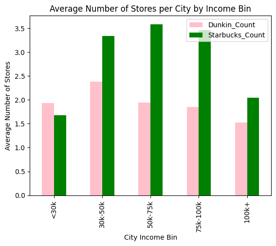

```python
# Prepare and clean the median income data
income_df = final_median_income_df.copy() # Make a copy of the final median income dataframe to maintain the original
income_df['state_name'] = income_df['state_name'].astype(str).str.title().map(state_to_abbrev).str.upper() # Map to state abbreviations, make uppercase, convert to string
income_df['Median'] = pd.to_numeric(income_df['Median'], errors='coerce') # Convert median income to numeric, invalid entries are NaN
income_df.dropna(subset=['city_name', 'state_name', 'Median'], inplace=True) # Remove rows missing city, state, or median income (cities must be shared between all three datasets for analysis)

# Take the median income if there are multiple entries per city
income_df = income_df.groupby(['city_name', 'state_name'])['Median'].median().reset_index()

# Merge the store counts with the median income per city
income_analysis_df = pd.merge(store_counts_df, income_df, on=['city_name', 'state_name'], how='inner')

# Create the bins for analysis
income_bins = [0, 30000, 50000, 75000, 100000, float('inf')]
income_labels = ['<30k', '30k-50k', '50k-75k', '75k-100k', '100k+']
income_analysis_df['Income_Bin'] = pd.cut(income_analysis_df['Median'], bins=income_bins, labels=income_labels, right=False) # .cut() assigns each city by median income to a bin

# Computer the average number of stores per income bin
density_by_income_bin = income_analysis_df.groupby('Income_Bin', observed=True)[['Dunkin_Count', 'Starbucks_Count']].mean()

# Create a bar plot
ax = density_by_income_bin.plot(
    kind='bar',
    color=['pink', 'green'], # Dunkin is pink Starbucks is green
)

ax.set_title('Average Number of Stores per City by Income Bin')
ax.set_xlabel('City Income Bin')
ax.set_ylabel('Average Number of Stores')
plt.show()
```

These patterns show us there is a correlation between median income levels and average store locations. Using this information, we can create a logistic regression model that will dive deeper into Research Question 2 and see exactly why there is a correlation. It also gives us the ability to bring in the population dataset to see if the household median income is impacted by the population size per city.

#### **Brand Dominance Cross Tabulation and Stacked Bar Chart**

```
Brand Presence Distribution by Income Bin:
Brand_Presence       Both  Dunkin Only  Starbucks Only
Income_Bin
<30k            29.347826    39.673913       30.978261
30k-50k         39.202082    29.575022       31.222897
50k-75k         38.583333    29.666667       31.750000
75k-100k        44.041451    26.424870       29.533679
100k+           41.628122    30.249769       28.122109
```

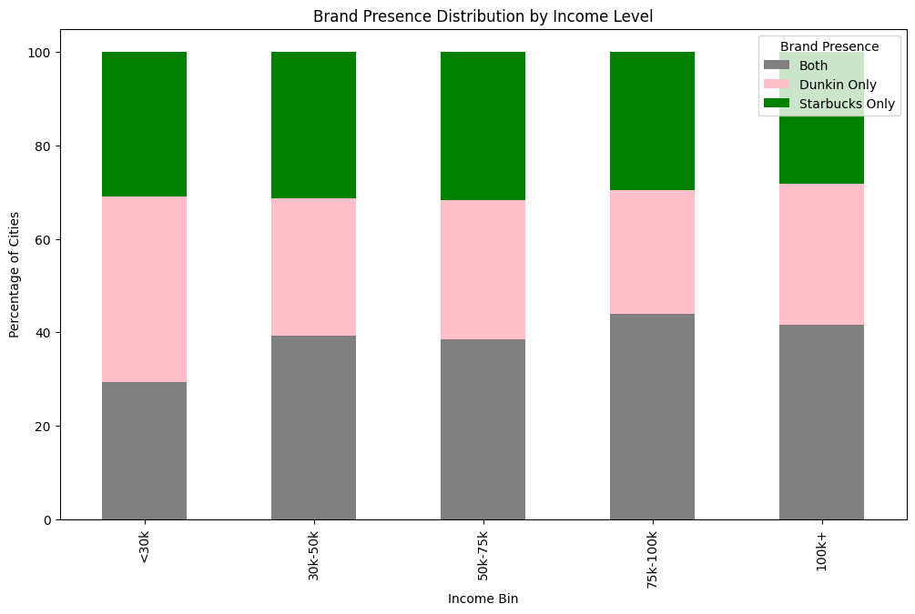

```python
# Create a function to classify the brand presence in each city
def classify_brand(row):
    # If a city contains both a Starbucks and a Dunkin
    if row['Starbucks_Count'] > 0 and row['Dunkin_Count'] > 0:
        return 'Both'
    # If a city only has a Starbucks
    elif row['Starbucks_Count'] > 0:
        return 'Starbucks Only'
    # If a city only has a Dunkin
    elif row['Dunkin_Count'] > 0:
        return 'Dunkin Only'
    # If a city doesn't have a Starbucks or Dunkin
    else:
        return 'Neither'

# Apply the function to create a new Brand_Presence column
income_analysis_df['Brand_Presence'] = income_analysis_df.apply(classify_brand, axis=1)

# Create a cross tabulation table to show brand presence per city, per income bin
dominance_table = pd.crosstab(
    income_analysis_df['Income_Bin'],
    income_analysis_df['Brand_Presence'],
    normalize='index'
) * 100

# View the cross tabulation table
print("Brand Presence Distribution by Income Bin:")
print(dominance_table)

# Define custom colors for our stacked bar
colors = {
    'Starbucks Only': 'green',
    'Dunkin Only': 'pink',
    'Both': 'gray',
    'Neither': 'lightgray'
}

# Create a stacked bar chart to visualize the distribution
ax2 = dominance_table.plot(
    kind='bar',
    stacked=True, # Must be true to activate stacking
    figsize=(12,7),
    color=[colors[col] for col in dominance_table.columns], # Set the custom colors
)

# Add titles, labels, and a legend
ax2.set_title("Brand Presence Distribution by Income Level")
ax2.set_xlabel("Income Bin")
ax2.set_ylabel("Percentage of Cities")
plt.legend(title="Brand Presence")
plt.show()
```

This stacked bar chart shows the market distribution across income levels. Based on the results of the graph, we can determine a few things:

- If high income cities have more Starbucks Only, it supports the idea that Starbucks targets higher income demographics
- If lower income cities have more Dunkin Only, it supports the idea that Dunkin targets lower income demographics.
- The Both category shows areas where the chains compete directly

Using percentages instead of raw counts lets us compare Dunkin and Starbucks fairly across the income groups. This graph directly answers Research Question 2: Does a city's median household income correlate with the presence of Starbucks and Dunkins? Having a visualization allows for immediate interpretation of our data prior to creating our model.

Interpretation of the graph:

- The Both category is relatively high for all columns, both increasing and decreasing.
  - The most competitive income bin is 75 k - 100 k.
- Dunkin only dominance is highest in the < 30 k income bin
  - This indicates Dunkin targets a lower income demographic
- Starbucks only dominance remains relatively consistent through each income bin
  - This does not show any direct correlation between Starbucks locations and income levels

This graph gives us the necessary information to build an accurate and efficient model.

### **General Statistics**

#### **Summary Table**

Create a summary table

```python
# Count the total Dunkin and Starbucks locations nationwide
starbucks_total_stores = len(final_starbucks_df)
dunkin_total_stores = len(final_dunkin)

# Count the total Dunkin and Starbucks locations in each state
starbucks_states = final_starbucks_df['state_name'].nunique()
dunkin_states = final_dunkin['state_name'].nunique()

# Calculate the total combined store count for both brands
combined_total_stores = starbucks_total_stores + dunkin_total_stores

# Calculate the market share for each brand (percentage of total stores)
starbucks_market_share = (starbucks_total_stores / combined_total_stores) * 100
dunkin_market_share = (dunkin_total_stores / combined_total_stores) * 100

# Calculate the average number of stores per state
starbucks_mean_stores = starbucks_total_stores / starbucks_states
dunkin_mean_stores = dunkin_total_stores / dunkin_states

# Calculate the maximum number of Starbucks and Dunkin locations in a single state
starbucks_max_stores = final_starbucks_df['state_name'].value_counts().max()
dunkin_max_stores = final_dunkin['state_name'].value_counts().max()

# Determine the top 5 states for Starbucks and Dunkin locations
starbucks_top_5_count = final_starbucks_df['state_name'].value_counts().head(5).sum()
dunkin_top_5_count = final_dunkin['state_name'].value_counts().head(5).sum()
starbucks_gci = (starbucks_top_5_count / starbucks_total_stores) * 100
dunkin_gci = (dunkin_top_5_count / dunkin_total_stores) * 100

# Calculate the share of all stores that exist in the top performing state for each
starbucks_top_state_ratio = (starbucks_max_stores / starbucks_total_stores) * 100
dunkin_top_state_ratio = (dunkin_max_stores / dunkin_total_stores) * 100

# Merge the Dunkin and Starbucks store count with the population by state into a single dataframe for each
starbucks_state_counts = final_starbucks_df.groupby('state_name').size().reset_index(name='store_count')
dunkin_state_counts = final_dunkin.groupby('state_name').size().reset_index(name='store_count')

# Get the total state populations from the dataset
state_population = final_population_df.groupby('state_name')['POPESTIMATE2020'].sum().reset_index()

# Constuct the table
summary_table_final = pd.DataFrame({
    'Brand': ['Starbucks', 'Dunkin'],
    'Total_Stores': [starbucks_total_stores, dunkin_total_stores],
    'States_Operated': [starbucks_states, dunkin_states],
    'Store_Market_Share (%)': [starbucks_market_share, dunkin_market_share],
    'Mean_Stores_per_State': [starbucks_mean_stores, dunkin_mean_stores],
    'Max_Stores_in_One_State': [starbucks_max_stores, dunkin_max_stores],
    'Geographic_Concentration_Index (%)': [starbucks_gci, dunkin_gci],
    'Top_State_Store_Ratio (%)': [starbucks_top_state_ratio, dunkin_top_state_ratio],
})
print(summary_table_final)
```

```
       Brand  Total_Stores  States_Operated  Store_Market_Share (%)  \
0  Starbucks         13608               51               59.537977
1     Dunkin          9248               45               40.462023

   Mean_Stores_per_State  Max_Stores_in_One_State  \
0             266.823529                     2821
1             205.511111                     1419

   Geographic_Concentration_Index (%)  Top_State_Store_Ratio (%)
0                           43.790417                  20.730453
1                           53.265571                  15.343858
```

1. Store Presence Across the United States
   - This gives us a baseline understanding of our datasets and their size.
   - As expected, Starbucks has more total stores and states of operation.
   - Dunkin is not far behind, showing a significant national presence.
   - These will tell us how widely each chain exists nationwide.
   - These statistics will allow us to look at geographical comparisons between states, cities, and regions.
2. Market Share
   - Market share lets us quantitatively show which chain is more dominant in the United States.
   - This helps us understand why we are seeing specific patterns in our data
     - For example; Starbucks having more average locations nationwide.
3. Average and Maximum Store Count
   - This helps us understand why we are seeing specific patterns in our data
   - This tells us if the stores are evenly or unevenly distributed.
4. Geographic Concentration Index
   - This determines what percentage of stores are in the top 5 states.
     - High GCI: Indicates the brand’s store count is highly clustered, suggesting a strong focus on a few key regional markets. This is the initial quantitative measure of regional roots.
     - Low GCI: Indicates a more even distribution of store volume across the country, indicating greater national spread.
   - This will help us answer: Which chain shows greater market saturation in its non-founding regions?
5. Top State Store Ratio
   - This will tell us how dependent a brand is on their top state's saturation in its non-founding regions
     - Low ratio means it is more evenly spread
     - High ratio means it is very concentrated
   - Will show regional disparities, and historical origins.

## **Logistic Regression Economic Correlation Model**

#### **Purpose**

The purpose of this model is to statistically quantify how two critical factors: historical regional origin and local economic conditions (median household income), independently influence the presence and competitive dominance of Dunkin' and Starbucks stores across U.S. cities. This analysis moves beyond simple observation to statistically prove that income and region are significant, independent predictors of a chain's market strategy, controlling for the natural variance of city population size.

#### **Dependent and Independent Variables**

#### **Binary Logistic Regression**

**Dependent Variables (Target)**

Create a binary indicator to show the presence of each chain.

- Starbucks_Present = 1, if a Starbucks exists in a city, 0 otherwise.
- Dunkin_Present = 1, if a Dunkin exists in a city, 0 otherwise.

##### **Independent Variables (Predictors)**

**Main Predictor:**

- Median
  - Median household income, Standard Scaled
  - Main economic predictor

**Control Variables:**

- POPESTIMATE2020
  - City population estimate
  - Log transformed and then Standard Scaled
  - Numeric, used as the control to account for cities that have a higher population and therefore more stores.
- Founding_Region
  - Indicates whether a city falls within either Starbucks or Dunkins founding region
  - Starbucks_Founding_Region = 1, if the store is in the Starbucks founding region
  - Dunkin_Founding_Region = 1, if the store is in the Dunkin founding region

#### **Multinomial Logistic Regression**

**Dependent Variables (Categorical)**

Additionally, we will use a Dominant_Brand variable to perform multinomial logistic regression to identify which specific market state a chain dominates

- Dominant_Brand = 0, if neither chain exists
  - Starbucks_Count = 0 and Dunkin_Count = 0
- Dominant_Brand = 1, if Starbucks stores dominate Dunkin stores
  - Starbucks_Count > Dunkin_Count
- Dominant_Brand = 2, if Dunkin stores dominate Starbucks stores
  - Dunkin_Count > Starbucks_Count
- Dominant_Brand = 3, if chains have an equal number of stores and both exist
  - Dunkin_Count = Starbucks_Count > 0

##### **Independent Variables (Predictors)**

**Main Predictor:**

- Median
  - Median household income, Standard Scaled
  - Main economic predictor

**Control Variables:**

- POPESTIMATE2020
  - City population estimate
  - Log transformed and then Standard Scaled
  - Numeric, used as the control to account for cities that have a higher population and therefore more stores.
- Founding_Region
  - Indicates whether a city falls within either Starbucks or Dunkins founding region
  - Starbucks_Founding_Region = 1, if the store is in the Starbucks founding region
  - Dunkin_Founding_Region = 1, if the store is in the Dunkin founding region

#### **Relation to EDA**

**Average Number of Stores per City by Income Bin - Bar Plot**

This bar plot provides the most direct visual evidence of our income correlation hypothesis.

**Observation 1 (Dunkin):**

Dunkin has its highest average store counts in the two lowest income bins. Additionally, the mean count decreases in higher bins.

- This pattern strongly suggests that median household income is a negative predictor of Dunkin presence.
- Our logistic regression model will formally test if the coefficient for Median is negative and statistically significant.

**Observation 2 (Starbucks):**

Starbucks has its lowest average store count in the lowest income bin. Starbucks reaches its peak in the middle income bins before decreasing at the highest income bin.

- This does not indcate any signficant patterns between Starbucks locations and income.
- Our logistic regression model will formally test if the coefficient for Median are neutral and statistically significant.

**Brand Presence Distribution by Income Levels - Stacked Bar Chart**

This bar chart provides context for market dominance and competition. This is the perfect use case for Multinomial Logistic Regression.

**Observation 1 (Dunkin Dominance):**  
This supports the use of multinomial logistic regression to specifically quantify how income levels influence the odds of a city being in a Dunkin dominant market, relative to other outcomes.

**Observation 2 (High Competition):**

The Equal Competition category (Dominant_Brand = 3) appears across all income bins and reaches its highest proportion in the 75 k - 100 k range. This indicates that mid-to-upper income cities are more likely to have a similar number of Starbucks and Dunkin stores, rather than clear dominance by one brand

- This supports including Dominant_Brand = 3 in the multinomial model. The model will quantify how income and regional factors shift the odds of a city having equal brand representation (co-presence) relative to Starbucks dominance
- Specifically, the model will test if the odds of intense competition decrease as median income rises, proving that the competitive balance is not sustained and that Starbucks converts the rising wealth above this threshold into its own solo dominance.

**State Level Summary Statistics - Summary Table**

Statistics like Geographic Concentration Index and Top State Store Ratio provide a baseline to interpret the magnitude of the Founding_Region Odds Ratios in the logistic regression.

#### **Model Methodology**

Our chosen methodology is Logistic Regression (Binary and Multinomial). Logistic regression models the probability that an observation belongs to a particular class. It does this by estimating how each predictor changes the log-odds of an outcome, which we make into Odds Ratios to interpret the effects. We chose Logistic over Linear Regression because our dependent variables are binary (Present/Absent) or categorical (Dominance, Competition), not continuous numerical data which is required for Linear Regression. In predictive modeling using logistic regression, data is usually split into training and testing sets to evaluate how well a model generalizes unseen data. This project however is an explanatory model instead of a predictive one. Therefore we fit the model on the full dataset for an explanatory process. We will validate our model by using AUC-ROC and accuracy.

**1. Data Merge and Cleaning**

This initial stage ensures our city-level data is complete and structured for analysis.

- Merging: Merge the Dunkin and Starbucks location data to get store counts per city. Merge the resulting store count data with the Median Household Income dataset to create income_analysis_df
- Data Quality: Remove any duplicate rows and drop any rows containing missing values in the critical predictor variables to ensure clean input for the models.

**2. Targets and Features**

- Create Target Variables
  - Binary Presence Indicator: Starbucks_Present and Dunkin_Present for the binary logistic regression model
  - Categorical Presence Indicator: Dominant_Brand for the multinomial logistic regression model
- Create Regional Predictors
  - Starbucks_Founding_Region and Dunkin_Founding_Region
- Log Transform Population
  - Apply a natural logarithm transformation POPESTIMATE2020 to the raw population data. This is necessary because city population data is heavily right-skewed, which is problematic for stable regression fitting.

**3. Scaling**

This final preparation step standardizes the continuous predictors to ensure they contribute equally to the model fitting process.

- Scale Predictors
  - Scale the continous, independent variables (Median Income and POPESTIMATE2020 Log Transform)

**4. Binary Logistic Regression**

This is the first analytical stage, used to confirm the initial income correlation and regional hypotheses. (Research Question 1, 2, and 3)

- **Model Fitting:** Fit two separate Binary Logistic Regression models: one for Starbucks_Present and one for Dunkin_Present.
- **Test Hypothesis:** The Odds Ratio quantifies the directional change (positive/negative) in the odds of presence, dependent on income and independent of population and regional factors, allowing for a comparative analysis of national reach.

**5. Multinomial Logistic Regression**

This is the final analytical stage which provides the comprehensive market structure analysis required to answer our research questions.

#### **Model Implementation**

```python
# Create a new dataframe "final_analysis_df" by merging dataframes city_analysis_df and income_df
# on an inner join for city_name and state_name. This matches rows where both city name and state name are the same in both tables
final_analysis_df = pd.merge(
    city_analysis_df,
    income_df,
    on=['city_name', 'state_name'],
    how='inner'
)

# Remove potential duplicate rows that may have resulted from merging non-unique data sources
final_analysis_df.drop_duplicates(subset=['city_name', 'state_name'], inplace=True)

# Filter our rows that might have NaN in their critical predictors after the merge.
# We do this since logistic regression cannot handle NaN's.
final_analysis_df.dropna(subset=['Median', 'POPESTIMATE2020'], inplace=True)

# Dispay the first 5 rows of our final, cleaned and merged dataframe
print(final_analysis_df.head())

#       TARGET AND CONTROL VARIABLES

# Here we are creating our Binary targets which will show the presence of the stores. We do this by creating a new column "Starbucks_Present" and "Dunkin_Present"
# which is a boolean series. True (or 1) if there is at least one Starbucks and 0 if there are none. Same thing for Dunkin.
final_analysis_df['Starbucks_Present'] = (final_analysis_df['Starbucks_Count'] > 0).astype(int)
final_analysis_df['Dunkin_Present'] = (final_analysis_df['Dunkin_Count'] > 0).astype(int)

# Here we are creating our Control Variables, which is Founding Region (also our indicators).
# We create two lists of State name abbreviations to define the founding states for each, Starbucks and Dunkin.
# Then our columns for "Dunkin_Founding_Region" and "Starbucks_Founding_Region" are in our final_analysis dataframe, with a 0/1 indicator for whether
# a store is in the founding region or not. Returns 1, or true if the store is found in one of the states, listed in founding states.
dunkin_founding_states = ['MA', 'CT', 'RI', 'ME', 'PA', 'VT', 'NH', 'NJ', 'NY']
final_analysis_df['Dunkin_Founding_Region'] = np.isin(final_analysis_df['state_name'], dunkin_founding_states).astype(int)

starbucks_founding_states = ['WA', 'OR', 'CA', 'MT', 'UT', 'HI', 'ID', 'WY', 'NV', 'CO', 'NM', 'AZ', 'AK']
final_analysis_df['Starbucks_Founding_Region'] = np.isin(final_analysis_df['state_name'], starbucks_founding_states).astype(int)

# Now we will create our Categorical Target which is Dominant_Brand
# First we create a helper function "classify_dominance" and use DataFrame.apply to classify the market state of each city based off store counts.
# The function takes a single row from the dataframe and returns 0 if neither brand is present, 1 if Starbucks has more stores than Dunkin, 2 if Dunkin
# has more stores than Starbucks, and 3 if both store counts are positive and equal (same amount of stores.
def classify_dominance(row):
    if row['Starbucks_Count'] == 0 and row['Dunkin_Count'] == 0:
        return 0
    elif row['Starbucks_Count'] > row['Dunkin_Count']:
        return 1
    elif row['Dunkin_Count'] > row['Starbucks_Count']:
        return 2
    else: # Dunkin_Count == Starbucks_Count > 0
        return 3
# Applies classify_dominance to each row of final_analysis_df. "axis=1" tells the functions go row-wise instead of column-wise
# Our returned values 0-3, are stored in the "Dominant_Brand" column. This will be our target variable for the multinomial model.
final_analysis_df['Dominant_Brand'] = final_analysis_df.apply(classify_dominance, axis=1)


#       SCALE CONTINUOUS PREDICTORS

# Create a log transformed population variable. We use numpy to apply log to each population value.
# This is important because our population is right skewed, and logistic regression works poorly with skewed data.
final_analysis_df['POPESTIMATE2020_Log'] = np.log(final_analysis_df['POPESTIMATE2020'])
scaler = StandardScaler() # uses StandardScaler object from skicitlearn
# Standardize the median income column. fit_transform will calculate the mean and stddev of Median income and then transform by subtracting the mean and divide by stddev for each val.
final_analysis_df['Median_Scaled'] = scaler.fit_transform(final_analysis_df[['Median']])
# Standardize the population variable the same way, with fit_transform
final_analysis_df['POPESTIMATE2020_Scaled'] = scaler.fit_transform(final_analysis_df[['POPESTIMATE2020_Log']])


#       DEFINE PREDICTORS (X) and TARGETS (Y)

# Create a list of column names we want for our predictors
X_cols = [
    'Median_Scaled',
    'POPESTIMATE2020_Scaled',
    'Starbucks_Founding_Region',
    'Dunkin_Founding_Region'
]

# Create the feature matrix X by selecting the predictor columns from dataframe
# This will be used as input for our models.
X = final_analysis_df[X_cols]
# Target vector for the Starbucks presence binary logistic regression
# contains 0 or 1 values (1 if city has Starbucks)
Y_starbucks = final_analysis_df['Starbucks_Present']
# Target vector for the Dunkin presence binary logistic regression
# contains 0 or 1 values (1 if city has Dunkin)
Y_dunkin = final_analysis_df['Dunkin_Present']
# Target vector for the multinomial logistic regression.
# contains values 0-3, representing which brand is dominant, neither present, or equal competition (discussed earlier)
Y_dominance = final_analysis_df['Dominant_Brand']


#       MODEL FITTING
#    Binary: Starbucks Presence
# Exclude the Dunkin region indicator for this starbucks presence model.
X_starbucks = X.drop(columns=['Dunkin_Founding_Region'])
# Fit a logistic regression model for starbucks presence using "LogisticRegression".
# solver='lbfgs' works best for the size of our datasets, is a quasi-Newton optimization method
# max_iter=1000 increases the max number of optimization iterations, since more iterations are better for logistic regression to converge with scaled data and multiple predictors.
starbucks_model = LogisticRegression(solver='lbfgs', max_iter=1000).fit(X_starbucks, Y_starbucks)

#     Binary: Dunkin Presence
# Exclude Starbucks region indicator for the Dunkin presence model
X_dunkin = X.drop(columns=['Starbucks_Founding_Region'])
# Fit a logistic regression model for Dunkin presence the same way we did above.
dunkin_model = LogisticRegression(solver='lbfgs', max_iter=1000).fit(X_dunkin, Y_dunkin)

#    Multinomial: Market Dominance
#  Fit a multinomial regression model
# solver='lbfgs' also works best for a multunomial model, and we fit on the chosen target and indicator.
multinomial_model = LogisticRegression(
    solver='lbfgs', # Good for multinomial problems
    max_iter=1000
).fit(X, Y_dominance)

#       VALIDATION METRICS

# Calculate AUC-ROC score for Binary Models
# We use the probability of the positive class (index 1) for the score
starbucks_auc = roc_auc_score(Y_starbucks, starbucks_model.predict_proba(X_starbucks)[:, 1])
dunkin_auc = roc_auc_score(Y_dunkin, dunkin_model.predict_proba(X_dunkin)[:, 1])

# First, we generate predictions for the entire dataset (X).
Y_dominance_pred = multinomial_model.predict(X)

# Then, we compare the model's predictions (Y_dominance_pred) to the true market outcomes (Y_dominance)
# This calculates the percentage of cities where the competitive outcome was correctly classified.
multinomial_accuracy = accuracy_score(Y_dominance, Y_dominance_pred)

#       RESULTS TABLE

# Helper function to extract and format results for the binary models.
# Builds a results dataframe with Predictor as the name predictors. model.coef_[0] creates an array of a 1d vector of coefficients
def extract_sklearn_binary_results(model, model_name, X_cols_used):
    results = pd.DataFrame({
        'Predictor': X_cols_used,
        'Coefficient': model.coef_[0],
        'Odds_Ratio': np.exp(model.coef_[0]) #Converts from log-odds scale to odds ratio scale, meaning OR>1 increaes odds and OR <1 decreases odds.
    })
    results['Model'] = model_name # Add a model column so we know which model each row came from
    return results

# Extract and combine binary results by calling the helper function on starbucks model and dunkin model.
# Result is in binary_results_df dataframe and will be a table with predictors, coefficients, odds ratios, and the corresponding model
binary_results_df = pd.concat([
    extract_sklearn_binary_results(starbucks_model, 'Starbucks Presence', X_starbucks.columns.tolist()),
    extract_sklearn_binary_results(dunkin_model, 'Dunkin Presence', X_dunkin.columns.tolist())
]).reset_index(drop=True)


# Function to process and format results for the multinomial model
def process_sklearn_multinomial_results(model, X_cols):

    # Target classes
    classes = model.classes_ # 0, 1, 2, 3

    # Map classes to readable statuses
    category_map = {
        0: 'Neither (Baseline)',
        1: 'Starbucks Dom',
        2: 'Dunkin Dom',
        3: 'Equal Comp'
    }

    multinomial_list = []
    # Iterate through coefficients for each class (k-1 classes are outputted)
    for i, class_id in enumerate(classes[1:]): # classes[1:] skips class (0)
        comparison_name = f"{category_map[class_id]} vs. {category_map[classes[0]]}"

        cat_df = pd.DataFrame({
            'Predictor': X_cols, # Predictor names
            'Coefficient': model.coef_[i], # Coefficients for this class
            'Odds_Ratio': np.exp(model.coef_[i]), # Odds ratios are exponential coefficients
            'Comparison': comparison_name # The class we are using for comparison
        })
        multinomial_list.append(cat_df) # add this class's results table to the list
# Get all class tables into a single dataframe and reset index
    return pd.concat(multinomial_list).reset_index(drop=True)
# Call helper function on the fitted multinomial model and predictor list
multinomial_results_df = process_sklearn_multinomial_results(multinomial_model, X_cols)
```

```
   city_name state_name  Dunkin_Count  Starbucks_Count  POPESTIMATE2020  \
0   ABERDEEN         MD           3.0              0.0            16270
2   ABERDEEN         NC           1.0              1.0             8625
4   ABERDEEN         SD           0.0              2.0            28437
8   ABERDEEN         WA           0.0              2.0            17037
10   ABILENE         TX           1.0              6.0           125230

    Dunkin_Density  Starbucks_Density   Median
0         1.843884           0.000000  80370.0
2         1.159420           1.159420  61786.0
4         0.000000           0.703309  46703.0
8         0.000000           1.173916  80209.0
10        0.079853           0.479118  36234.0
```

```python
# Print validation metrics
print("MODEL VALIDATION METRICS:\n")
print(f"Starbucks Presence AUC-ROC Score: {starbucks_auc:.3f}")
print(f"Dunkin Presence AUC-ROC Score: {dunkin_auc:.3f}")
print(f"Multinomial Dominance Accuracy Score: {multinomial_accuracy:.3f}\n")

# Print our final binary logistic regression results
print("FINAL BINARY LOGISTIC REGRESSION RESULTS")
print("-" * 80)
print(binary_results_df[['Model', 'Predictor', 'Coefficient', 'Odds_Ratio']].to_markdown(index=False, floatfmt=".3f"))

# Print our final multinomial logistic regression results
print("\nFINAL MULTINOMIAL LOGISTIC REGRESSION RESULTS")
print("-" * 80)
print(multinomial_results_df[['Comparison', 'Predictor', 'Coefficient', 'Odds_Ratio']].to_markdown(index=False, floatfmt=".3f"))
```

[output not shown]

## **Insight**

### **Research Question 1**

**Question:**  
Does the region of historical origin, the Northeast for Dunkin and the West for Starbucks, significantly affect the current geospatial presence of stores?

**Insight:**  
Yes, the region of historical origin is the strongest, most significant predictor of store presence for both chains. Confirming that historical roots remain the primary constraint on national deployment. However, the effect is more pronounced for Starbucks. This is answered in the Founding Region predictor of the Binary Logistic Regression model.

**Model:**  
Binary Logistic Regression Model

**Observations:**

- Starbucks_Founding_Region Odds Ratio: 55.285
- Dunkin_Founding_Region Odds Ratio: 31.883

**Analysis:**  
We can say the odds of a city having a Starbucks are 55.285 times greater if the city is in its founding region (West Coast), holding all other factors (Income, Population) constant. We can also infer the odds of a city having a Dunkin are 31.883 times greater if the city is in its founding region (Northeast), holding all other factors (Income, Population) constant.

When comparing these odds ratios to every other predictor, we see they dominate in every category. Confirming a large and highly significant geospatial dependence on their founding region. This established geospatial dependence is the necessary prerequisite for analyzing the comparison of market strategies in the following questions.

### **Research Question 2**

**Question:**  
Does a city's median household income correlate with the presence of Starbucks and Dunkin'?

**Model:**  
Binary Logistic Regression Model

**Observations:**

- Starbucks Presence Median_Scaled Odds Ratio: 1.016 (Greater than 1)
- Dunkin' Presence Median_Scaled Odds Ratio: 0.834 (Less than 1)
- Starbucks Presence POPESTIMATE2020_SCALED Odds Ratio: 4.146
- Dunkin' Presence POPESTIMATE2020_SCALED Odds Ratio: 1.210

**Analysis:**

From these results, we can say that for every standard deviation increase in income, the odds of a city having a Starbucks increase by a marginal 1.6%. We can also infer that for Dunkin, the odds decrease by 16.6%. This shift proves Starbucks is highly neutral toward income once geographic effects are controlled, while Dunkin targets lower to middle income demographics.

The odds ratio for POPESTIMATE2020_SCALED also confirms this observation. Starbucks' odds ratio of 4.146 indicates that for every one standard deviation increase in log-transformed population, the odds of a city having a Starbucks increase by over 314%. This confirms that Starbucks' strategy is heavily focused on highly dense metropolitan areas.

For Dunkin at 1.210, while population is a positive factor, the magnitude is far less intense, leading to only an 21% increase in odds for a one standard deviation population increase.

### **Research Question 3**

**Question:**  
Which chain is less reliant on its founding region for store existence, indicating greater national market reach and geographical spread?

**Model:**  
Comparative analysis of the Binary Logistic Regression Model used in Research Question 1

**Observations:**

- Starbucks Presence Starbucks_Founding_Region Odds Ratio: 55.285
- Dunkin' Presence Dunkin_Founding_Region Odds Ratio: 31.883

**Analysis:**  
A lower odds ratio indicates a flatter distribution. This means the odds of finding a Dunkin store are less constrained by its founding region (the Northeast) than the odds of finding a Starbucks store are by its founding region (the West Coast).

### **Research Question 4**

**Question:**  
Which chain converts its founding region status into stronger competitive dominance and greater store density over its rival?

**Insight:**  
Starbucks converts its home region status into superior competitive dominance, confirming its strategy of high-intensity saturation and density clustering.

**Model:**  
Multinomial Logistic Regression Model

**Observations:**

**Analysis:**

This result proves that in its home region, Starbucks uses its advantage to establish undisputed solo dominance (a high density of stores leading to Starbucks Count > Dunkin Count) rather than being forced into a market where both chains have equal store counts. This confirms their strategy of vertical expansion (high intensity). Dunkin's home region strength results in a highly contested market, but not superior solo dominance over Starbucks.

## **Validation**

### **Binary Logistic Regression**

The Area Under the Receiver Operating Characteristic Curve (AUC-ROC) is a critical metric for binary classification models. It measures the model's ability to distinguish between the two classes (Present/Absent). The score ranges from 0 to 1, where 0.5 is random chance, and 1.0 is a perfect model.

- Starbucks AUC-ROC: 0.864
  - This score is considered to be very good. It suggests that if we randomly selected one city with a Starbucks and one city without, the model would correctly predict which city has the Starbucks 86.4% of the time.
  - This high score confirms that our chosen predictors (Income, Population, and Founding Region) are highly effective at explaining Starbucks' geographic footprint.
- Dunkin AUC-ROC: 0.722
  - This score is generally considered good. The lower value compared to Starbucks may be due to the nature of Dunkin's strategy:
    - Broader Market: Dunkin's presence is less exclusively tied to the high-income/high-population clusters that our Census data is most precise about.
    - Less Predictable: The brand's focus on smaller towns and non-incorporated areas.

#### **Visualizing Binary Logistic Regression: Probability of Presence vs. Median Income**

To visualize the impact of median income on the probability of a store's presence, we will plot the predicted probabilities from our binary logistic regression models.

We need to generate a range of `Median_Scaled` values and then use our trained models to predict the probability of a store being present across this income range. For other predictors, we will hold them constant to isolate the effect of income.

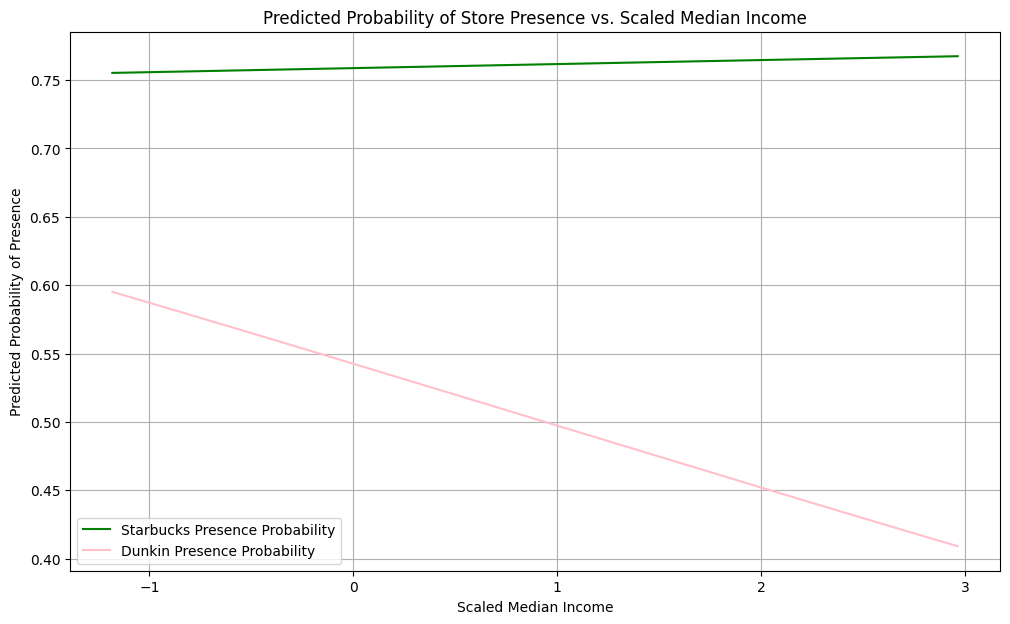

```python
# Range of scaled median income values for plotting
median_scaled_range = np.linspace(X['Median_Scaled'].min(), X['Median_Scaled'].max(), 300).reshape(-1, 1)

# Hold other predictors constant at their mean or a representative value
# For POPESTIMATE2020_Scaled, use the mean
mean_pop_scaled = X['POPESTIMATE2020_Scaled'].mean()

# For Founding_Region, assume non-founding region (0)
non_founding_region = 0

# DataFrame for Starbucks predictions
X_starbucks_plot = pd.DataFrame({
    'Median_Scaled': median_scaled_range.flatten(),
    'POPESTIMATE2020_Scaled': np.full(median_scaled_range.shape[0], mean_pop_scaled),
    'Starbucks_Founding_Region': np.full(median_scaled_range.shape[0], non_founding_region)
})

# Predict probabilities for Starbucks presence
starbucks_prob = starbucks_model.predict_proba(X_starbucks_plot)[:, 1]

# DataFrame for Dunkin predictions
X_dunkin_plot = pd.DataFrame({
    'Median_Scaled': median_scaled_range.flatten(),
    'POPESTIMATE2020_Scaled': np.full(median_scaled_range.shape[0], mean_pop_scaled),
    'Dunkin_Founding_Region': np.full(median_scaled_range.shape[0], non_founding_region)
})

# Predict probabilities for Dunkin presence
dunkin_prob = dunkin_model.predict_proba(X_dunkin_plot)[:, 1]

plt.figure(figsize=(12, 7))
plt.plot(median_scaled_range, starbucks_prob, label='Starbucks Presence Probability', color='green')
plt.plot(median_scaled_range, dunkin_prob, label='Dunkin Presence Probability', color='pink')

plt.title('Predicted Probability of Store Presence vs. Scaled Median Income')
plt.xlabel('Scaled Median Income')
plt.ylabel('Predicted Probability of Presence')
plt.legend()
plt.grid(True)
plt.show()
```

This plot visually confirms the insights from the Odds Ratios:

- **Starbucks (Green Line):** The probability of Starbucks presence slightly increases with scaled median income. This aligns with the `Median_Scaled` Odds Ratio of 1.016, indicating a marginal positive correlation.
- **Dunkin (Pink Line):** The probability of Dunkin presence decreases as scaled median income increases. This matches the `Median_Scaled` Odds Ratio of 0.834, showing a negative correlation.

This plot clearly demonstrates the different strategies of Starbucks and Dunkin in relation to local economic conditions.

### **Multinomial Logistic Regression**

The Multinomial Dominance Accuracy Score measures the percentage of cities where the model correctly predicted the competitive category (Starbucks Dominant, Dunkin Dominant, Equal Comp, or Neither).

- Accuracy Score: 0.756
  - An accuracy of 75% is strong for a multi-class model. It demonstrates that the four predictor variables are robust enough to not only predict simple presence but also the intensity and nature of the market competition between the two brands at the city level.

### **Conclusions**

The primary goal of this project was to understand how a brand's historical origin and local economic conditions determine its current market presence and competetive dominance against its main rival, using U.S cities as the unit of analysis.

We used two distinct statistical models to answer our 4 research questions

- Binary Logistic Regression
  - Used to predict the simple presence (existence) of a store for each chain. This model was key for measuring national reach and economic correlation.
- Multinomial Logistic Regression
  - Used to predict the ultimate competitive outcome (Dominant Starbucks, Dominant Dunkin', Equal Comp, or Neither). This model was key for measuring competitive intensity and dominance.
- Predictors
  - Scaled Median Income, Scaled Population, and a binary indicator for the chain's Founding Region.

These models confirmed that the two chains operate in fundamentally non-overlapping economic markets. Starbucks' positive Odds Ratio (1.016) and high density correlation confirm that Starbucks targets cities characterized by high population density and, marginally, higher income, while Dunkin targets lower to middle income cities.

Dunkin has successfully executed a strategy that reaches broad geographic expansion and economic segmentation, making stores more accessible across less affluent cities. Conversly, Starbucks has perfected a strategy of high-density clustering and high intensity saturation. This creates deep concentrations of stores in dense metropolitan areas.

```python
from google.colab import drive
drive.mount('/content/drive')
```

```python
%%shell
jupyter nbconvert --to html "/content/drive/MyDrive/Data_Science_Project.ipynb"
```

[output not shown]

[output cut: 136 more lines]

[output not shown]

[output not shown]